# Predicting Urban Bike Sharing Demand with ML Models

## Project Objective

The **"Predicting Urban Bike Sharing Demand with ML Models"** project aims to develop a machine learning model to predict bike-sharing demand in urban areas using historical data. The objectives are to:

1. **Analyze** key factors (e.g., weather, time, seasonality) that influence demand.
2. **Build a predictive model** to forecast bike-sharing demand accurately.
3. **Optimize bike distribution** by identifying high-demand locations and times.
4. **Improve urban mobility** by enhancing the efficiency of bike-sharing systems.

This project addresses the problem of inefficient bike allocation, where bikes are either in surplus or shortage at key locations and times.

**Expected Outcome:** Forecasts bike demand to optimize distribution and improve system efficiency.

**Dataset:** [Bike Sharing Demand Dataset](https://www.kaggle.com/competitions/bike-sharing-demand/data)

### Notebook Structure:

- About Dataset
- Data Summary
- Data Summary Statistics
- Exploratory Data Analysis (EDA)
- Correlation Analysis
- Data Distribution Visualization
- Visualizing the Relationship Between Variables and Bike Rentals (Count)
- Visualizing Demand Trends Across DateTime
- Visualizing Bike Rentals Trend by Hour Across Different Categories
- Categorical Feature Handling
- Feature Selection
- Splitting Data into Training and Development (Validation) Data
- Model Training
- Linear Regression Model
- XGBoost Regression
- XGBoost Regression with Hyperparameter Tuning
- XGBoost Regression with Regularization Techniques
- Summary
- Additional: Investigating the Role of Windspeed in Residuals
- Additional: Imputing Windspeed Values with Random Forest
- Additional: Linear Regression Model After Imputation

## About Dataset

### Overview

Bike-sharing systems enable users to rent bicycles through automated kiosks, with over 500 programs worldwide. These systems generate valuable data, including trip duration, locations, and timing, acting as a sensor network for studying urban mobility. By combining historical usage data with weather information, bike-sharing demand can be forecasted for better resource management.

### Data Fields

- datetime - hourly date + timestamp
- season - 1 = spring, 2 = summer, 3 = fall, 4 = winter
- holiday - whether the day is considered a holiday
- workingday - whether the day is neither a weekend nor holiday
- weather -
  - 1: Clear, Few clouds, Partly cloudy, Partly cloudy
  - 2: Mist + Cloudy, Mist + Broken clouds, Mist + Few clouds, Mist
  - 3: Light Snow, Light Rain + Thunderstorm + Scattered clouds, Light Rain + Scattered clouds
  - 4: Heavy Rain + Ice Pallets + Thunderstorm + Mist, Snow + Fog
- temp - temperature in Celsius
- atemp - "feels like" temperature in Celsius
- humidity - relative humidity
- windspeed - wind speed
- casual - number of non-registered user rentals initiated
- registered - number of registered user rentals initiated
- count - number of total rentals

#### Import Library

```python
import pandas as pd
from tqdm import tqdm
import seaborn as sns
import matplotlib.pyplot as plt
import seaborn as sns
from sklearn.model_selection import train_test_split, GridSearchCV, cross_val_score
from sklearn.linear_model import LogisticRegression
from sklearn.metrics import accuracy_score, confusion_matrix, classification_report
from sklearn.metrics import precision_score, recall_score, f1_score, roc_auc_score, roc_curve
from sklearn.preprocessing import StandardScaler, OneHotEncoder
import numpy as np
from sklearn.linear_model import LinearRegression
from sklearn.metrics import mean_squared_error, r2_score, mean_squared_log_error, mean_absolute_error
from sklearn.model_selection import KFold
import xgboost as xgb
import pickle

# for random forest imputation
from sklearn.ensemble import RandomForestRegressor
from sklearn.impute import SimpleImputer

pd.set_option('display.max_colwidth', None)
import warnings
from sklearn.exceptions import ConvergenceWarning
warnings.filterwarnings("ignore", category=ConvergenceWarning)
```

#### Load dataset from GitHub

```python
# Path for train and test data
train_data_path = 'https://raw.githubusercontent.com/GopinathAchuthan/Predicting-Urban-Bike-Sharing-Demand-with-ML-Models/refs/heads/main/train.csv'
test_data_path = 'https://raw.githubusercontent.com/GopinathAchuthan/Predicting-Urban-Bike-Sharing-Demand-with-ML-Models/refs/heads/main/test.csv'
```

```python
# Read the CSV file
train_data_raw = pd.read_csv(train_data_path)

#test_data_raw = pd.read_csv(test_data_path)
```

## Data Summary

As a first step, let's perform the following tasks on the dataset:

- Check the dataset shape.
- Preview the data by printing a few rows.
- Identify the types of variables (categorical, numerical, etc.).

#### Dataset Information

```python
train_data_raw.info()
```

```
<class 'pandas.core.frame.DataFrame'>
RangeIndex: 10886 entries, 0 to 10885
Data columns (total 12 columns):
 #   Column      Non-Null Count  Dtype
---  ------      --------------  -----
 0   datetime    10886 non-null  object
 1   season      10886 non-null  int64
 2   holiday     10886 non-null  int64
 3   workingday  10886 non-null  int64
 4   weather     10886 non-null  int64
 5   temp        10886 non-null  float64
 6   atemp       10886 non-null  float64
 7   humidity    10886 non-null  int64
 8   windspeed   10886 non-null  float64
 9   casual      10886 non-null  int64
 10  registered  10886 non-null  int64
 11  count       10886 non-null  int64
dtypes: float64(3), int64(8), object(1)
memory usage: 1020.7+ KB
```

#### Dataset Shape

```python
print("Train Dataset Shape:", train_data_raw.shape)
# print("Test Dataset Shape:", test_data_raw.shape)
```

```
Train Dataset Shape: (10886, 12)
```

#### Sample of First few rows

```python
train_data_raw.head()
```

|  | datetime | season | holiday | workingday | weather | temp | atemp | humidity | windspeed | casual | registered | count |
| --- | --- | --- | --- | --- | --- | --- | --- | --- | --- | --- | --- | --- |
| 0 | 2011-01-01 00:00:00 | 1 | 0 | 0 | 1 | 9.84 | 14.395 | 81 | 0.0 | 3 | 13 | 16 |
| 1 | 2011-01-01 01:00:00 | 1 | 0 | 0 | 1 | 9.02 | 13.635 | 80 | 0.0 | 8 | 32 | 40 |
| 2 | 2011-01-01 02:00:00 | 1 | 0 | 0 | 1 | 9.02 | 13.635 | 80 | 0.0 | 5 | 27 | 32 |
| 3 | 2011-01-01 03:00:00 | 1 | 0 | 0 | 1 | 9.84 | 14.395 | 75 | 0.0 | 3 | 10 | 13 |
| 4 | 2011-01-01 04:00:00 | 1 | 0 | 0 | 1 | 9.84 | 14.395 | 75 | 0.0 | 0 | 1 | 1 |

#### Note:

The sum of Casual and Registered equals Count, but these two feature columns are not present in the test set. Therefore, Casual and Registered cannot be used directly in the prediction model. $$ Casual + Registered = Count $$

## Data Summary Statistics

```python
# Full statistics summary
train_data_numeric = train_data_raw.select_dtypes(include=[np.number])  # Selecting numeric columns
full_stats = train_data_numeric.describe().transpose()

# Adding skewness and kurtosis for each column
full_stats['skewness'] = train_data_numeric.skew()
full_stats['kurtosis'] = train_data_numeric.kurt()

# Display the full summary
full_stats
```

|  | count | mean | std | min | 25% | 50% | 75% | max | skewness | kurtosis |
| --- | --- | --- | --- | --- | --- | --- | --- | --- | --- | --- |
| season | 10886.0 | 2.506614 | 1.116174 | 1.00 | 2.0000 | 3.000 | 4.0000 | 4.0000 | -0.007076 | -1.355661 |
| holiday | 10886.0 | 0.028569 | 0.166599 | 0.00 | 0.0000 | 0.000 | 0.0000 | 1.0000 | 5.660517 | 30.046975 |
| workingday | 10886.0 | 0.680875 | 0.466159 | 0.00 | 0.0000 | 1.000 | 1.0000 | 1.0000 | -0.776163 | -1.397828 |
| weather | 10886.0 | 1.418427 | 0.633839 | 1.00 | 1.0000 | 1.000 | 2.0000 | 4.0000 | 1.243484 | 0.395533 |
| temp | 10886.0 | 20.230860 | 7.791590 | 0.82 | 13.9400 | 20.500 | 26.2400 | 41.0000 | 0.003691 | -0.914530 |
| atemp | 10886.0 | 23.655084 | 8.474601 | 0.76 | 16.6650 | 24.240 | 31.0600 | 45.4550 | -0.102560 | -0.850076 |
| humidity | 10886.0 | 61.886460 | 19.245033 | 0.00 | 47.0000 | 62.000 | 77.0000 | 100.0000 | -0.086335 | -0.759818 |
| windspeed | 10886.0 | 12.799395 | 8.164537 | 0.00 | 7.0015 | 12.998 | 16.9979 | 56.9969 | 0.588767 | 0.630133 |
| casual | 10886.0 | 36.021955 | 49.960477 | 0.00 | 4.0000 | 17.000 | 49.0000 | 367.0000 | 2.495748 | 7.551629 |
| registered | 10886.0 | 155.552177 | 151.039033 | 0.00 | 36.0000 | 118.000 | 222.0000 | 886.0000 | 1.524805 | 2.626081 |
| count | 10886.0 | 191.574132 | 181.144454 | 1.00 | 42.0000 | 145.000 | 284.0000 | 977.0000 | 1.242066 | 1.300093 |

#### Key Takeaways:

- **Skewed Distributions**: Features such as **Holiday**, **Casual Riders**, **Registered Riders**, and **Bike Count** have significant skewness, indicating imbalanced or highly variable data that might need special handling in modeling.
- **Time-related Features**: Temporal features like **Hour**, **Day of Week**, and **Month** show distinct patterns of bike usage, which is expected due to the nature of bike rentals varying with time.
- **Temperature and Humidity**: There is a moderate impact of **temperature** and **humidity** on the bike count, with temperature having a positive correlation and humidity negatively affecting bike demand.
- **Data Range**: Some features, such as **Windspeed** and **Bike Count**, contain extreme outliers, which could be important for predictions but might require normalization or transformation.

## Exploratory Data Analysis (EDA)

#### Copying the Raw Dataset

To ensure that the original raw dataset remains unchanged during the data preprocessing steps, we create a copy of it. This allows us to safely perform transformations, handle missing values, or conduct any data cleaning on the copied dataset, while preserving the integrity of the original raw data for reference or future use.

```python
data = train_data_raw.copy()
# test_data = test_data_raw.copy()
```

#### Converting Necessary Columns to Datetime Format

```python
# Convert the 'datetime' column to pandas datetime format
data["datetime"] = pd.to_datetime(data["datetime"])
```

#### Missing Value Handling

```python
# Check for missing values
print('Missing value count in train data:')
missing_values = data.isnull().sum()
print(missing_values)
```

```
Missing value count in train data:
datetime      0
season        0
holiday       0
workingday    0
weather       0
temp          0
atemp         0
humidity      0
windspeed     0
casual        0
registered    0
count         0
dtype: int64
```

**Note:** Upon inspecting the dataset, it was found that there are no missing values in any of the columns. Therefore, no imputation or removal of missing data is required for this analysis.

## Correlation Analysis

```python
data.corr()
```

|  | datetime | season | holiday | workingday | weather | temp | atemp | humidity | windspeed | casual | registered | count |
| --- | --- | --- | --- | --- | --- | --- | --- | --- | --- | --- | --- | --- |
| datetime | 1.000000 | 0.480021 | 0.010988 | -0.003658 | -0.005048 | 0.180986 | 0.181823 | 0.032856 | -0.086888 | 0.172728 | 0.314879 | 0.310187 |
| season | 0.480021 | 1.000000 | 0.029368 | -0.008126 | 0.008879 | 0.258689 | 0.264744 | 0.190610 | -0.147121 | 0.096758 | 0.164011 | 0.163439 |
| holiday | 0.010988 | 0.029368 | 1.000000 | -0.250491 | -0.007074 | 0.000295 | -0.005215 | 0.001929 | 0.008409 | 0.043799 | -0.020956 | -0.005393 |
| workingday | -0.003658 | -0.008126 | -0.250491 | 1.000000 | 0.033772 | 0.029966 | 0.024660 | -0.010880 | 0.013373 | -0.319111 | 0.119460 | 0.011594 |
| weather | -0.005048 | 0.008879 | -0.007074 | 0.033772 | 1.000000 | -0.055035 | -0.055376 | 0.406244 | 0.007261 | -0.135918 | -0.109340 | -0.128655 |
| temp | 0.180986 | 0.258689 | 0.000295 | 0.029966 | -0.055035 | 1.000000 | 0.984948 | -0.064949 | -0.017852 | 0.467097 | 0.318571 | 0.394454 |
| atemp | 0.181823 | 0.264744 | -0.005215 | 0.024660 | -0.055376 | 0.984948 | 1.000000 | -0.043536 | -0.057473 | 0.462067 | 0.314635 | 0.389784 |
| humidity | 0.032856 | 0.190610 | 0.001929 | -0.010880 | 0.406244 | -0.064949 | -0.043536 | 1.000000 | -0.318607 | -0.348187 | -0.265458 | -0.317371 |
| windspeed | -0.086888 | -0.147121 | 0.008409 | 0.013373 | 0.007261 | -0.017852 | -0.057473 | -0.318607 | 1.000000 | 0.092276 | 0.091052 | 0.101369 |
| casual | 0.172728 | 0.096758 | 0.043799 | -0.319111 | -0.135918 | 0.467097 | 0.462067 | -0.348187 | 0.092276 | 1.000000 | 0.497250 | 0.690414 |
| registered | 0.314879 | 0.164011 | -0.020956 | 0.119460 | -0.109340 | 0.318571 | 0.314635 | -0.265458 | 0.091052 | 0.497250 | 1.000000 | 0.970948 |
| count | 0.310187 | 0.163439 | -0.005393 | 0.011594 | -0.128655 | 0.394454 | 0.389784 | -0.317371 | 0.101369 | 0.690414 | 0.970948 | 1.000000 |

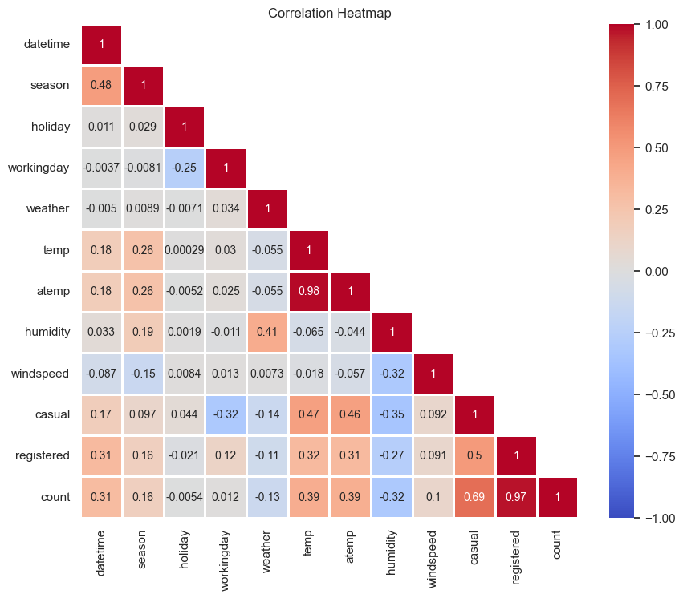

```python
# Set the style for focusing to be entirely on the data without distractions
sns.set(style="white")

# Correlation Heatmap
cor_mat = data.corr()
mask = np.array(cor_mat.copy())
mask[np.tril_indices_from(mask)] = False
plt.figure(figsize=(10,8))
sns.heatmap(cor_mat, mask=mask, annot=True, cmap='coolwarm', linewidths=1.0, annot_kws={"size": 10}, vmin=-1, vmax=1)
plt.title('Correlation Heatmap')
plt.show()
```

## Data Distribution Visualization

### Frequency and Density Plots

A frequency and density plot combines histograms and Kernel Density Estimation (KDE) to visualize the distribution of data. It helps identify patterns, understand the shape of the distribution, and detect outliers. This combined approach simplifies complex datasets, highlights trends, and supports data analysis and predictive modeling.

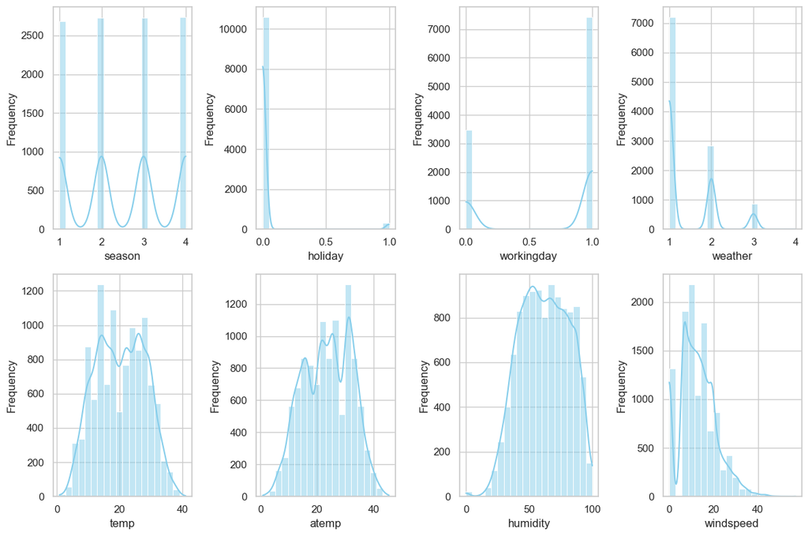

```python
# Set the style for better aesthetics in the plot
sns.set(style="whitegrid")

# List of columns to visualize with histograms and KDE
columns_to_plot = ['season', 'holiday', 'workingday', 'weather', 'temp', 'atemp', 'humidity', 'windspeed']

# Plotting histograms for the selected columns
plt.figure(figsize=(12, 8))

for i, column in enumerate(columns_to_plot, 1):
    plt.subplot(2, 4, i)  # 2 rows, 4 columns
    sns.histplot(data[column], kde=True, bins=20, color='skyblue')
    plt.xlabel(column)
    plt.ylabel('Frequency')


# Adjust layout to prevent overlap
plt.tight_layout()
plt.show()
```

Note:

### Box Plots

This provides a graphical representation of the distribution of a dataset. It displays key statistical summaries such as the median, quartiles, and potential outliers. Box plots help visualize the spread, central tendency, and symmetry of data, making it easier to identify variations, detect outliers, and compare distributions across different categories or groups.

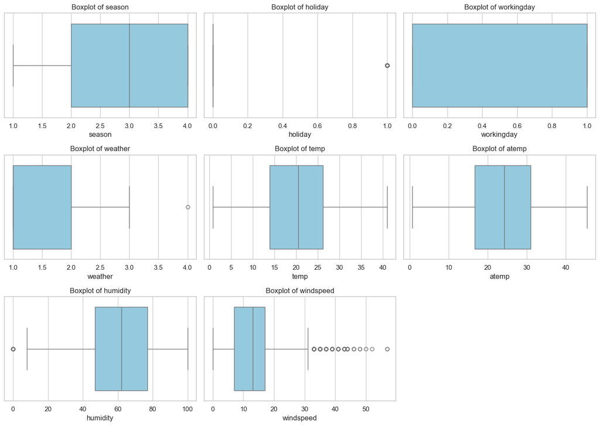

```python
# Set the style for better aesthetics in the plot
sns.set(style="whitegrid")

# List of columns to visualize with boxplots
columns_to_plot = ['season', 'holiday', 'workingday', 'weather', 'temp', 'atemp', 'humidity', 'windspeed']

# Plotting boxplots for the selected columns
plt.figure(figsize=(14, 10))

for i, column in enumerate(columns_to_plot, 1):
    plt.subplot(3, 3, i)  # 3 rows, 3 columns (adjust grid size accordingly)
    sns.boxplot(x=data[column], color='skyblue')
    plt.title(f'Boxplot of {column}')
    plt.xlabel(column)

# Adjust layout to prevent overlap
plt.tight_layout()
plt.show()
```

Note:

- **Windspeed:** There are a few outliers with windspeed values greater than 30. These outliers might represent unusual weather conditions or data entry anomalies. It's important to investigate or decide whether these values significantly impact bike rental patterns, especially in relation to weather and rental activity.

## Visualizing the Relationship Between Variables and Bike Rentals (Count)

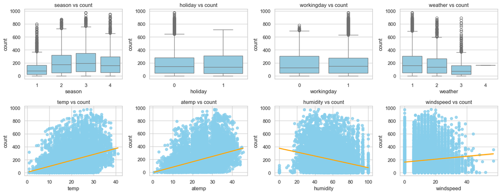

```python
# Set the style for better aesthetics in the plot
sns.set(style="whitegrid")

# List of columns to visualize
categorical_columns = ['season', 'holiday', 'workingday', 'weather']
continuous_columns = ['temp', 'atemp', 'humidity', 'windspeed']
column_y = 'count'

# Plotting the relationships between the columns and 'count'
plt.figure(figsize=(16, 12))

# Plot for categorical variables (boxplots)
for i, column in enumerate(categorical_columns, 1):
    plt.subplot(4, 4, i)  # 2 rows, 2 columns for categorical variables
    sns.boxplot(x=data[column], y=data[column_y], color='skyblue')
    plt.title(f'{column} vs {column_y}')
    plt.xlabel(column)
    plt.ylabel(column_y)

# Plot for continuous variables (regression plots)
for i, column in enumerate(continuous_columns, 1):
    plt.subplot(4, 4, i + 4)  # 2 rows, 2 columns for continuous variables (starting at position 5)
    sns.regplot(x=data[column], y=data[column_y], scatter_kws={'color': 'skyblue'}, line_kws={'color': 'orange'})
    plt.title(f'{column} vs {column_y}')
    plt.xlabel(column)
    plt.ylabel(column_y)

# Set the main title for the figure
# plt.suptitle('Relationship Between Variables and Bike Rentals (Count)', fontsize=16, y=1.02)

# Adjust layout to prevent overlap
plt.tight_layout()
plt.show()
```

## Visualizing Demand Trends Across DateTime

#### Feature Creation: Extracting time-based feature from the 'datetime' column

```python
# Extract following time-based feature from the 'datetime' column:
    # - 'hour': Hour of the day (0-23)
    # - 'day': Day of the month (1-31)
    # - 'day_of_week': Day of the week (0 = Monday, 6 = Sunday)
    # - 'month': Month of the year (1-12)
    # - 'year': Year extracted from the datetime
data["hour"] = data["datetime"].dt.hour
data["day"] = data["datetime"].dt.day
data["weekday"] = data["datetime"].dt.dayofweek
data["month"] = data["datetime"].dt.month
data["year"] = data["datetime"].dt.year
```

```python
year_count = data['year'].value_counts()
year_count
```

```
year
2012    5464
2011    5422
Name: count, dtype: int64
```

#### Bike Rental Demand Trends

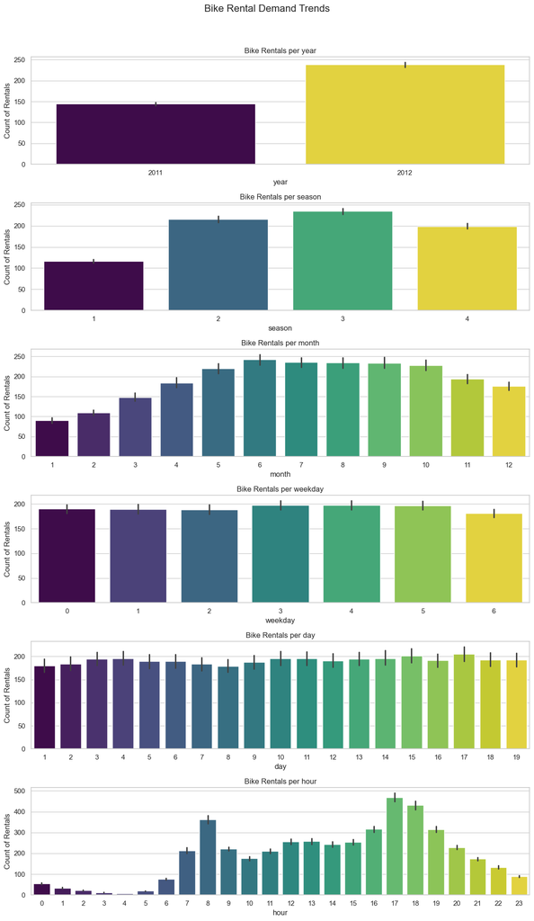

```python
# Set the style for better aesthetics in the plot
sns.set(style="whitegrid")

# Create a figure for plotting
plt.figure(figsize=(12, 20))

# List of columns to visualize with barplot
columns_to_plot = ['year', 'season', 'month', 'weekday', 'day', 'hour']
column_y = 'count'

for i, column in enumerate(columns_to_plot, 1):
    plt.subplot(6, 1, i)
    sns.barplot(x=column, y=column_y, data=data, palette='viridis', hue=column, legend=False)
    plt.title(f'Bike Rentals per {column}')
    plt.xlabel(column)
    plt.ylabel('Count of Rentals')

# Set the main title for the figure
plt.suptitle('Bike Rental Demand Trends', fontsize=16, y=1.02)

# Adjust layout to prevent overlap
plt.tight_layout()
plt.show()
```

## Visualizing Bike Rentals Trend by Hour Across Different Categories

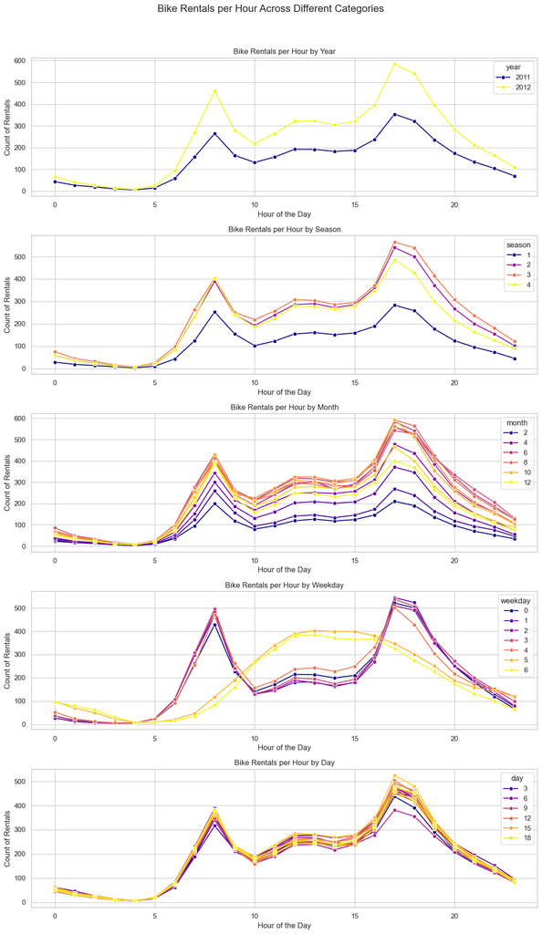

```python
# Set the style for better aesthetics in the plot
sns.set(style="whitegrid")

# Create a figure for plotting
plt.figure(figsize=(12, 20))

# List of columns to visualize with barplot
columns_to_plot = ['year', 'season', 'month', 'weekday', 'day']  # Categories to plot across
column_x = 'hour'
column_y = 'count'

# Create subplots for each category
for i, column in enumerate(columns_to_plot, 1):
    plt.subplot(5, 1, i)  # Create 4 rows, 1 column
    sns.lineplot(x=column_x, y=column_y, hue=column, data=data, palette='plasma', marker='o', errorbar=None)
    # sns.lineplot(x='hour', y=column_y, hue=column, data=data, palette='viridis', marker='o')
    plt.title(f'Bike Rentals per Hour by {column.capitalize()}')
    plt.xlabel('Hour of the Day')
    plt.ylabel('Count of Rentals')

# Set the main title for the figure
plt.suptitle('Bike Rentals per Hour Across Different Categories', fontsize=16, y=1.02)

# Adjust layout to prevent overlap
plt.tight_layout()
plt.show()
```

## Categorical Feature Handling

```python
data.columns
```

```
Index(['datetime', 'season', 'holiday', 'workingday', 'weather', 'temp',
       'atemp', 'humidity', 'windspeed', 'casual', 'registered', 'count',
       'hour', 'day', 'weekday', 'month', 'year'],
      dtype='object')
```

```python
# One-Hot Encoding for categorical features
categorical_features = ['season', 'holiday', 'workingday', 'weather', 'hour', 'month', 'year', 'weekday']
```

One-hot encoding is used in this prediction model to convert categorical variables (e.g., season, weather, holiday, etc.) into numerical format. This allows machine learning algorithms to process them effectively without assuming any inherent order or relationship between categories, ensuring better model performance.

**Note:** The 'day' feature is excluded from the encoding process as it does not contribute meaningful information for model prediction.

```python
# Initialize the encoder
encoder = OneHotEncoder(drop='first', sparse_output=False)

# Fit and transform the categorical features
encoded_features = encoder.fit_transform(data[categorical_features])

# Ensure you have the correct number of columns in encoded features
encoded_feature_names = encoder.get_feature_names_out(categorical_features)

# Convert the encoded features into a DataFrame with the correct column names
encoded_df = pd.DataFrame(encoded_features, columns=encoded_feature_names)

# Reset index of both DataFrames to ensure proper alignment
data = data.drop(categorical_features, axis=1).reset_index(drop=True)
encoded_df = encoded_df.reset_index(drop=True)

# Reset index to align with the original DataFrame if necessary
data = pd.concat([data, encoded_df], axis=1)
```

```python
data.columns
```

```
Index(['datetime', 'temp', 'atemp', 'humidity', 'windspeed', 'casual',
       'registered', 'count', 'day', 'season_2', 'season_3', 'season_4',
       'holiday_1', 'workingday_1', 'weather_2', 'weather_3', 'weather_4',
       'hour_1', 'hour_2', 'hour_3', 'hour_4', 'hour_5', 'hour_6', 'hour_7',
       'hour_8', 'hour_9', 'hour_10', 'hour_11', 'hour_12', 'hour_13',
       'hour_14', 'hour_15', 'hour_16', 'hour_17', 'hour_18', 'hour_19',
       'hour_20', 'hour_21', 'hour_22', 'hour_23', 'month_2', 'month_3',
       'month_4', 'month_5', 'month_6', 'month_7', 'month_8', 'month_9',
       'month_10', 'month_11', 'month_12', 'year_2012', 'weekday_1',
       'weekday_2', 'weekday_3', 'weekday_4', 'weekday_5', 'weekday_6'],
      dtype='object')
```

#### One-Hot Encoding and Dropping the First Category

In **One-Hot Encoding**, we use `drop='first'` to avoid **multicollinearity** by removing the first category in each feature. This prevents redundancy, as the presence of the dropped category can be inferred from the other categories. For example, **season_1** (Spring) is dropped because its presence can be inferred when none of the other seasons are active.

#### Missing Columns:

After encoding, columns like **season_1**, **holiday_0**, and **weather_1** are missing because they are dropped as the reference categories.

#### Why Drop the First Category:

This method helps avoid issues with correlated predictors in models, especially linear regression. If needed, we can keep all categories by removing `drop='first'`, though this could introduce multicollinearity.

#### One-Hot Encoding Mathematical explanation:

For the **season** feature, with values ({1, 2, 3, 4}), we encode it as follows:

Without dropping the first category: $$ \text{season} = \begin{cases} (1, 0, 0, 0) & \text{if season = 1} \\ (0, 1, 0, 0) & \text{if season = 2} \\ (0, 0, 1, 0) & \text{if season = 3} \\ (0, 0, 0, 1) & \text{if season = 4} \end{cases} $$

With **`drop='first'`**, we drop the first category (Spring, season = 1), and encode the remaining seasons with 3 columns: $$ \text{season} = \begin{cases} (0, 0, 0) & \text{if season = 1 (Spring)} \\ (1, 0, 0) & \text{if season = 2 (Summer)} \\ (0, 1, 0) & \text{if season = 3 (Fall)} \\ (0, 0, 1) & \text{if season = 4 (Winter)} \end{cases} $$

Here, the first season (Spring) is implicitly represented by the absence of other categories.

## Feature Selection

```python
data.columns
```

```
Index(['datetime', 'temp', 'atemp', 'humidity', 'windspeed', 'casual',
       'registered', 'count', 'day', 'season_2', 'season_3', 'season_4',
       'holiday_1', 'workingday_1', 'weather_2', 'weather_3', 'weather_4',
       'hour_1', 'hour_2', 'hour_3', 'hour_4', 'hour_5', 'hour_6', 'hour_7',
       'hour_8', 'hour_9', 'hour_10', 'hour_11', 'hour_12', 'hour_13',
       'hour_14', 'hour_15', 'hour_16', 'hour_17', 'hour_18', 'hour_19',
       'hour_20', 'hour_21', 'hour_22', 'hour_23', 'month_2', 'month_3',
       'month_4', 'month_5', 'month_6', 'month_7', 'month_8', 'month_9',
       'month_10', 'month_11', 'month_12', 'year_2012', 'weekday_1',
       'weekday_2', 'weekday_3', 'weekday_4', 'weekday_5', 'weekday_6'],
      dtype='object')
```

```python
columns_to_drop = ['datetime', 'atemp', 'casual', 'registered', 'season_2', 'season_3', 'season_4']
df = data.drop(columns=columns_to_drop)
df.columns
```

```
Index(['temp', 'humidity', 'windspeed', 'count', 'day', 'holiday_1',
       'workingday_1', 'weather_2', 'weather_3', 'weather_4', 'hour_1',
       'hour_2', 'hour_3', 'hour_4', 'hour_5', 'hour_6', 'hour_7', 'hour_8',
       'hour_9', 'hour_10', 'hour_11', 'hour_12', 'hour_13', 'hour_14',
       'hour_15', 'hour_16', 'hour_17', 'hour_18', 'hour_19', 'hour_20',
       'hour_21', 'hour_22', 'hour_23', 'month_2', 'month_3', 'month_4',
       'month_5', 'month_6', 'month_7', 'month_8', 'month_9', 'month_10',
       'month_11', 'month_12', 'year_2012', 'weekday_1', 'weekday_2',
       'weekday_3', 'weekday_4', 'weekday_5', 'weekday_6'],
      dtype='object')
```

#### Explanation of why these columns are dropped:

1. 'datetime' details are already extracted into separate features such as 'day', 'weekday', 'month', and 'year'. Therefore, the 'datetime' column is redundant and can be dropped.
2. 'atemp' (feels like temperature) and 'temp' (actual temperature) are highly correlated. Since 'atemp' is not an accurate representation of temperature and is derived from subjective human perception, we decided to drop 'atemp' and keep 'temp' as the more reliable feature.
3. The 'casual' and 'registered' columns represent non-registered and registered user rentals, respectively. The sum of these two columns equals the 'count' column, which is the target variable for forecasting. Additionally, 'casual' and 'registered' are not available in the test data, so they are dropped to avoid data leakage.
4. 'season_2', 'season_3', and 'season_4' represent seasons (spring, summer, fall, winter). However, the 'month' feature can capture the seasonality information effectively. Thus, we drop the season columns as they provide redundant information.

## Splitting Data into Training and Development (Validation) Data

```python
X = df.drop(columns='count')  # Features
y = df['count']  # Target variable
```

```python
# Split data into train and validation based on the 'day' column, since test data is from the 20th to the end of the month.
train_data = df[df['day'] <= 16]  # Training data: day 1 to 16
val_data = df[df['day'] >= 17]    # Validation data: day 17 to 19

# Separate features (X) and target (y)
X_train = train_data.drop(columns=['count', 'day'])  # Features for training data
y_train = train_data['count']  # Target variable for training data

X_dev = val_data.drop(columns=['count', 'day'])  # Features for validation data
y_dev = val_data['count']  # Target variable for validation data

# Checking the shapes of the train and validation datasets
print(f"Training data shape: X_train = {X_train.shape}")
print(f"Validation data shape: X_dev = {X_dev.shape}")
```

```
Training data shape: X_train = (9174, 49)
Validation data shape: X_dev = (1712, 49)
```

## Model Training

#### Choosing ML Models

1. **Linear Regression / Random Forest Regression**:
   - Start with traditional models to establish a baseline for prediction accuracy.
2. **XGBoost or Gradient Boosting Machines**:
   - Try advanced models like XGBoost for better handling of feature interactions and non-linear relationships.
3. **Neural Networks**:
   - If you have enough data and computational power, deep learning models like LSTM or feedforward neural networks can capture more complex patterns over time.

## Linear Regression

#### Training the linear model

```python
# Initialize the Linear Regression model
linear_model = LinearRegression()

# Train the model on the training data
linear_model.fit(X_train, y_train)

# Predict the target variable on the training set
y_pred_train = linear_model.predict(X_train)

# Ensure that the predictions are non-negative (since count can't be negative)
y_pred_train = np.maximum(0, y_pred_train)
```

```python
# Calculate performance metrics
mae = mean_absolute_error(y_train, y_pred_train)  # Mean Absolute Error
mse = mean_squared_error(y_train, y_pred_train)  # Mean Squared Error
rmse = np.sqrt(mse)  # Root Mean Squared Error (sqrt of MSE)
rmsle = mean_squared_log_error(y_train, y_pred_train) # Root Mean Squared Logarithmic Error
r2 = r2_score(y_train, y_pred_train)  # R-squared score

# Print all the metrics
print(f"Mean Absolute Error (MAE): {mae}")
print(f"Mean Squared Error (MSE): {mse}")
print(f"Root Mean Squared Error (RMSE): {rmse}")
print(f"Root Mean Squared Logarithmic Error (RMSLE): {rmsle}")
print(f"R-squared (R²): {r2}")
```

```
Mean Absolute Error (MAE): 68.96970931195506
Mean Squared Error (MSE): 9412.505191858907
Root Mean Squared Error (RMSE): 97.01806631684073
Root Mean Squared Logarithmic Error (RMSLE): 1.2352281486724455
R-squared (R²): 0.7126970463295751
```

#### Why RMSLE Can't Handle Negative Values:

Root Mean Squared Logarithmic Error (RMSLE) involves taking the logarithm of the predicted values. The logarithm of a negative number is undefined in real numbers. Since the target variable `count` represents non-negative values (like rentals), negative predictions would result in errors. Hence, we use `np.maximum(0, y_pred)` to ensure all predictions are non-negative before calculating the error.

#### RMSLE interpretation:

- RMSLE = 1.0: This means, on average, the logarithmic error between the actual and predicted values is about 1.
- RMSLE < 1.0: The model is relatively good at capturing the overall patterns.
- RMSLE > 1.0: The model might not be capturing the data well, especially in terms of predicting relative growth or magnitude of values.

#### Residual Plot for Training Data

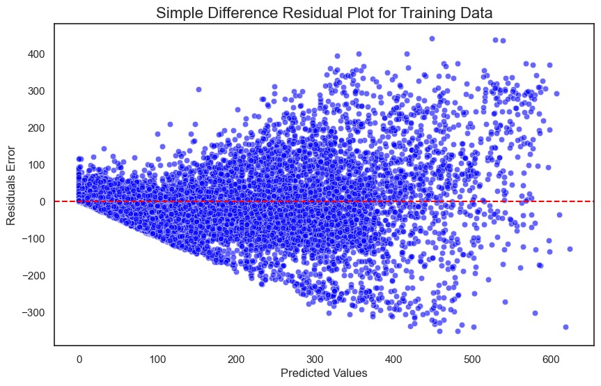

```python
# Calculate residuals
residuals_train = y_train - y_pred_train

# Plot residuals
plt.figure(figsize=(10, 6))
sns.scatterplot(x=y_pred_train, y=residuals_train, color='blue', alpha=0.6)

# Add a horizontal line at 0 (ideal residual line)
plt.axhline(y=0, color='red', linestyle='--')

# Title and labels
plt.title('Simple Difference Residual Plot for Training Data', fontsize=16)
plt.xlabel('Predicted Values', fontsize=12)
plt.ylabel('Residuals Error', fontsize=12)

# Show the plot
plt.show()
```

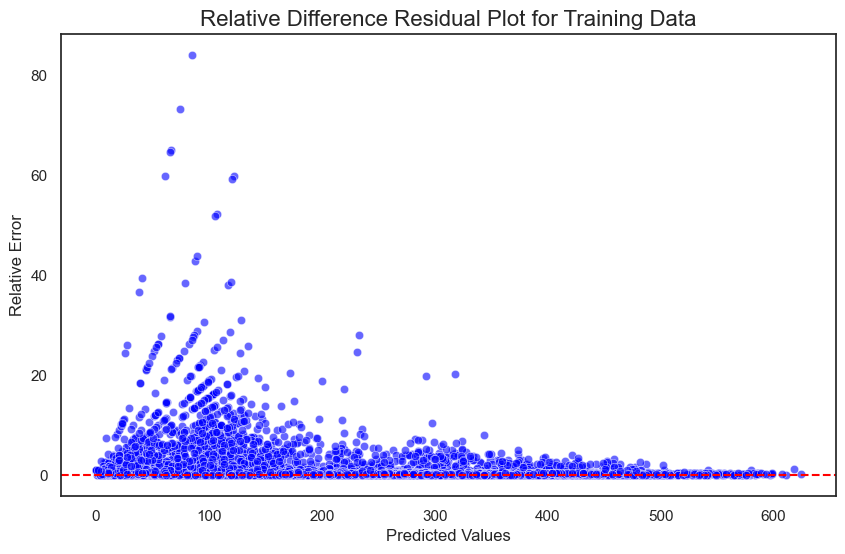

```python
# Calculate relative error
relative_error_train = np.abs(y_train - y_pred_train) / np.abs(y_train)

# Plot residuals
plt.figure(figsize=(10, 6))
sns.scatterplot(x=y_pred_train, y=relative_error_train, color='blue', alpha=0.6)

# Add a horizontal line at 0 (ideal residual line)
plt.axhline(y=0, color='red', linestyle='--')

# Title and labels
plt.title('Relative Difference Residual Plot for Training Data', fontsize=16)
plt.xlabel('Predicted Values', fontsize=12)
plt.ylabel('Relative Error', fontsize=12)

# Show the plot
plt.show()
```

#### Validating the Linear Model with Dev Data

```python
# Predict the target variable on the validation set
y_pred_dev = linear_model.predict(X_dev)

# Ensure that the predictions are non-negative (since count can't be negative)
y_pred_dev = np.maximum(0, y_pred_dev)
```

```python
# Calculate performance metrics
mae = mean_absolute_error(y_dev, y_pred_dev)  # Mean Absolute Error
mse = mean_squared_error(y_dev, y_pred_dev)  # Mean Squared Error
rmse = np.sqrt(mse)  # Root Mean Squared Error (sqrt of MSE)
rmsle = mean_squared_log_error(y_dev, y_pred_dev) # Root Mean Squared Logarithmic Error
r2 = r2_score(y_dev, y_pred_dev)  # R-squared score

# Print all the metrics
print(f"Mean Absolute Error (MAE): {mae}")
print(f"Mean Squared Error (MSE): {mse}")
print(f"Root Mean Squared Error (RMSE): {rmse}")
print(f"Root Mean Squared Logarithmic Error (RMSLE): {rmsle}")
print(f"R-squared (R²): {r2}")
```

```
Mean Absolute Error (MAE): 69.02962332986857
Mean Squared Error (MSE): 9664.342851616782
Root Mean Squared Error (RMSE): 98.30738960839507
Root Mean Squared Logarithmic Error (RMSLE): 1.2185033148442568
R-squared (R²): 0.7074752127132042
```

#### Residual Plot for Validation Data

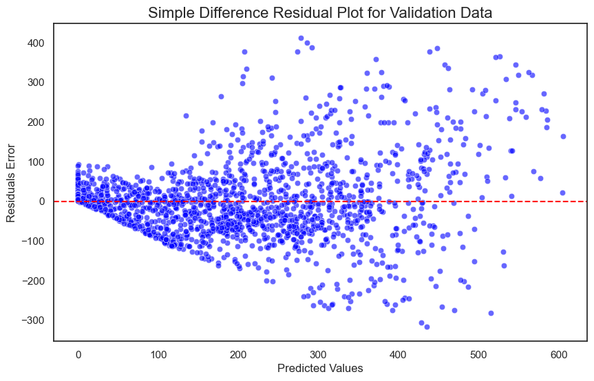

```python
# Calculate residuals
residuals_dev = y_dev - y_pred_dev

# Plot residuals
plt.figure(figsize=(10, 6))
sns.scatterplot(x=y_pred_dev, y=residuals_dev, color='blue', alpha=0.6)

# Add a horizontal line at 0 (ideal residual line)
plt.axhline(y=0, color='red', linestyle='--')

# Title and labels
plt.title('Simple Difference Residual Plot for Validation Data', fontsize=16)
plt.xlabel('Predicted Values', fontsize=12)
plt.ylabel('Residuals Error', fontsize=12)

# Show the plot
plt.show()
```

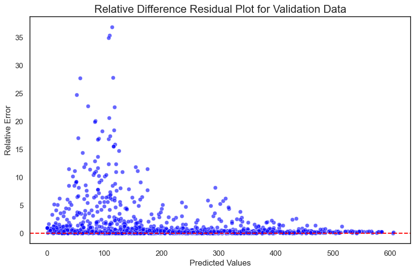

```python
# Calculate relative error
relative_error_dev = np.abs(y_dev - y_pred_dev) / np.abs(y_dev)

# Plot residuals
plt.figure(figsize=(10, 6))
sns.scatterplot(x=y_pred_dev, y=relative_error_dev, color='blue', alpha=0.6)

# Add a horizontal line at 0 (ideal residual line)
plt.axhline(y=0, color='red', linestyle='--')

# Title and labels
plt.title('Relative Difference Residual Plot for Validation Data', fontsize=16)
plt.xlabel('Predicted Values', fontsize=12)
plt.ylabel('Relative Error', fontsize=12)

# Show the plot
plt.show()
```

### Linear Model Performance Analysis and Observations:

1. **Prediction Accuracy**: The **R²** value of around 0.71 for both the training and validation sets indicates that the model is able to explain a substantial portion of the variance in bike rental demand. While this is a good fit, there is still 29% of variance unexplained by the model, which could be attributed to factors not included in the features (e.g., unaccounted external factors or more granular data).
2. **Minimal Overfitting**: The performance metrics on both the training and validation sets are very close to each other, particularly the **MAE**, **MSE**, and **R²** values. This suggests that the model is generalizing well and is not overfitting the training data. Additionally, the slight increases in error metrics (**MSE**, **RMSE**) on the validation set compared to the training set are normal and indicate that the model's performance on new, unseen data is slightly worse but still within an acceptable range. This further confirms that the model is not overfitting and is capable of handling new data with reasonable accuracy.
3. **Model Evaluation**:
   - **MSE**: The **Mean Squared Error** penalizes larger errors more heavily. This value is relatively high, suggesting that there are instances where the model’s predictions are significantly off from the actual values.
   - **RMSLE**: The **Root Mean Squared Logarithmic Error** (1.24) is useful for measuring the relative error. A value of 1.24 suggests that the model’s predictions are reasonably accurate in terms of percentage deviations but still leave room for improvement.
4. **Overall Performance**: Overall, the model demonstrates good performance with a moderate level of predictive accuracy (**R² = 0.71**). The metrics suggest that the model is well-suited for predicting bike rental demand, but there may be room for improvement by exploring more advanced models (e.g., **Random Forest**, **XGBoost**) or incorporating additional features.

#### Challenges in Assuming a Linear Relationship in the Dataset

Based on the training and validation metrics of the linear model, it is difficult to conclude that the target feature has a linear relationship with the independent features. The model's performance suggests that the relationship may be more complex, potentially involving non-linear patterns, interactions, or other issues like multicollinearity and outliers. Given that the dataset contains outliers, noise, interactive features, and multicollinearity, it's even more challenging to assume a linear relationship between the target and independent variables.

#### Linear Model coefficients Analysis

```python
# Coefficients of the model
coefficients = pd.DataFrame({
    'Feature': X_train.columns,
    'Coefficient': linear_model.coef_
})

print(coefficients.sort_values(by='Coefficient', ascending=False))
```

```
         Feature  Coefficient
24       hour_17   383.165822
25       hour_18   349.670042
15        hour_8   310.495169
26       hour_19   239.606900
23       hour_16   227.596767
19       hour_12   175.227238
20       hour_13   171.652828
14        hour_7   167.750435
22       hour_15   164.485242
16        hour_9   163.057166
27       hour_20   158.504644
21       hour_14   154.070081
18       hour_11   134.251177
17       hour_10   107.722751
```

[output cut: 35 more lines]

## XGBoost Regression

```python
# Initialize the XGBoost model
xg_reg = xgb.XGBRegressor(objective='reg:squarederror',
                          colsample_bytree=0.3,
                          learning_rate=0.1,
                          max_depth=5,
                          n_estimators=100)

# Train the model
xg_reg.fit(X_train, y_train)

# Make predictions on the train data
y_pred_train = xg_reg.predict(X_train)

# Ensure that the predictions are non-negative (since count can't be negative)
y_pred_train = np.maximum(0, y_pred_train)

# Make predictions on the validation data
y_pred_dev = xg_reg.predict(X_dev)

# Ensure that the predictions are non-negative (since count can't be negative)
y_pred_dev = np.maximum(0, y_pred_dev)
```

```python
# Calculate performance metrics for train data
mae = mean_absolute_error(y_train, y_pred_train)  # Mean Absolute Error
mse = mean_squared_error(y_train, y_pred_train)  # Mean Squared Error
rmse = np.sqrt(mse)  # Root Mean Squared Error (sqrt of MSE)
rmsle = mean_squared_log_error(y_train, y_pred_train) # Root Mean Squared Logarithmic Error
r2 = r2_score(y_train, y_pred_train)  # R-squared score

# Print all the metrics
print(f"Mean Absolute Error (MAE): {mae}")
print(f"Mean Squared Error (MSE): {mse}")
print(f"Root Mean Squared Error (RMSE): {rmse}")
print(f"Root Mean Squared Logarithmic Error (RMSLE): {rmsle}")
print(f"R-squared (R²): {r2}")
```

```
Mean Absolute Error (MAE): 48.07219218121119
Mean Squared Error (MSE): 4560.641184039728
Root Mean Squared Error (RMSE): 67.53251945573871
Root Mean Squared Logarithmic Error (RMSLE): 0.6301706280904146
R-squared (R²): 0.8607931137084961
```

```python
# Calculate performance metrics for dev data
mae = mean_absolute_error(y_dev, y_pred_dev)  # Mean Absolute Error
mse = mean_squared_error(y_dev, y_pred_dev)  # Mean Squared Error
rmse = np.sqrt(mse)  # Root Mean Squared Error (sqrt of MSE)
rmsle = mean_squared_log_error(y_dev, y_pred_dev) # Root Mean Squared Logarithmic Error
r2 = r2_score(y_dev, y_pred_dev)  # R-squared score

# Print all the metrics
print(f"Mean Absolute Error (MAE): {mae}")
print(f"Mean Squared Error (MSE): {mse}")
print(f"Root Mean Squared Error (RMSE): {rmse}")
print(f"Root Mean Squared Logarithmic Error (RMSLE): {rmsle}")
print(f"R-squared (R²): {r2}")
```

```
Mean Absolute Error (MAE): 52.42546830355912
Mean Squared Error (MSE): 5757.540434130661
Root Mean Squared Error (RMSE): 75.8784583009609
Root Mean Squared Logarithmic Error (RMSLE): 0.6697833343215072
R-squared (R²): 0.8257280588150024
```

### XGBoost Regression Performance Analysis and Observations

The performance metrics for the **XGBoost regression model** on both the **training set** and **validation set** show improvements in predictive accuracy compared to the linear model. Let’s analyze these metrics in detail:

#### **Training Set Performance (XGBoost):**

1. **Mean Absolute Error (MAE):** 48.07
   - The MAE is **48.07**, indicating that, on average, the model's predictions deviate from the actual values by about **48 rentals**. This is a notable improvement over the linear model’s MAE of **68.97**.
2. **Mean Squared Error (MSE):** 4560.64
   - The MSE is **4560.64**, which is considerably lower than the linear model’s **9412.51**. This suggests that XGBoost performs better in minimizing large errors.
3. **Root Mean Squared Error (RMSE):** 67.53
   - The RMSE of **67.53** is significantly lower than the linear model’s RMSE of **97.02**, indicating a much better overall predictive performance. This reflects that the XGBoost model has reduced the average error by almost **29 rentals**.
4. **Root Mean Squared Logarithmic Error (RMSLE):** 0.63
   - The RMSLE of **0.63** is a significant improvement over the linear model’s **1.24**. This indicates that the model is more accurate in predicting the relative error, especially for cases where the demand is lower.
5. **R-squared (R²):** 0.86
   - The R-squared value of **0.86** shows that **86% of the variance** in the bike rental count is explained by the model. This is a strong improvement over the linear model’s R² of **0.71**, suggesting much better overall model fit and predictive power.

#### **Validation Set Performance (XGBoost):**

1. **Mean Absolute Error (MAE):** 52.43
   - The MAE on the validation set is **52.43**, which is a bit higher than the training set but still significantly lower than the linear model’s validation MAE of **69.03**. This indicates that the XGBoost model generalizes well but there is a small increase in error on unseen data.
2. **Mean Squared Error (MSE):** 5757.54
   - The MSE of **5757.54** on the validation set is higher than the training MSE, which is common as the model encounters unseen data. However, it’s still lower than the linear model's validation MSE of **9664.34**, which reflects better generalization.
3. **Root Mean Squared Error (RMSE):** 75.88
   - The RMSE of **75.88** on the validation set is higher than the training RMSE, but it’s still a significant improvement over the linear model’s validation RMSE of **98.31**. The slight increase is expected when the model is tested on new data.
4. **Root Mean Squared Logarithmic Error (RMSLE):** 0.67
   - The RMSLE on the validation set is **0.67**, which is better than the linear model’s **1.22**, showing that the XGBoost model consistently performs better even on unseen data, particularly for lower demand values.
5. **R-squared (R²):** 0.83
   - The R-squared value of **0.83** on the validation set is slightly lower than the training set but still represents a strong model fit. Compared to the linear model’s R² of **0.71** on the validation set, this is a clear improvement.

#### **Key Observations:**

- **Improvement Over Linear Model:** The XGBoost model outperforms the linear regression model across almost all metrics. Notably, **MAE**, **MSE**, **RMSE**, and **R²** are significantly better with XGBoost, showing that the model can more accurately predict bike-sharing demand.
- **Consistency in Generalization:** While the validation set performance is slightly worse than the training set performance (which is expected), the increase in error is relatively small. This indicates that XGBoost is not overfitting and generalizes well to unseen data, with a **R² of 0.83** on the validation set.
- **Relative Performance (RMSLE):** The lower **RMSLE** for the XGBoost model on both the training and validation sets highlights the model’s ability to better predict relative errors, especially for low-demand scenarios, making it more robust for various types of bike-sharing data.
- **Model Complexity and Fit:** The **R² of 0.86** on the training set and **0.83** on the validation set suggests that XGBoost does a much better job of capturing the underlying patterns in the data compared to linear regression, which is limited by its linear assumptions.

In conclusion, the **XGBoost regression model** significantly improves predictive accuracy compared to the linear model, offering better performance in almost every metric. It reduces the **error rates**, increases **R-squared** values, and performs better on unseen data, making it a more suitable choice for forecasting bike-sharing demand in urban areas. This model’s superior performance makes it a strong candidate for real-world deployment in bike-sharing systems, potentially optimizing bike distribution and improving system efficiency.

## XGBoost Regression with Hyperparameter Tuning

GridSearchCV automates hyperparameter tuning by testing all combinations within a defined grid. It uses cross-validation to evaluate model performance, ensuring the best combination of parameters is selected. This improves model accuracy but can be computationally expensive with large grids.

```python
# Define the parameter grid for XGBoost
param_grid = {
    'learning_rate': [0.01, 0.05, 0.1, 0.2],       # Learning rate (shrinkage)
    'max_depth': [3, 5, 7, 10],                    # Maximum depth of the tree
    'n_estimators': [80, 120, 200],                # Number of boosting rounds
    'subsample': [0.7, 0.8, 1.0],                  # Proportion of data used for each tree
    'colsample_bytree': [0.7, 0.8, 1.0],           # Proportion of features used for each tree
}

# Initialize XGBoost regressor
xg_reg = xgb.XGBRegressor(objective='reg:squarederror')

# Set up GridSearchCV with cross-validation
grid_search = GridSearchCV(estimator=xg_reg, param_grid=param_grid,
                           scoring='neg_mean_squared_error', cv=3, n_jobs=-1, verbose=2)

# Fit GridSearchCV to the training data
grid_search.fit(X_train, y_train)
```

```
Fitting 3 folds for each of 432 candidates, totalling 1296 fits
```

```
GridSearchCV(cv=3,
             estimator=XGBRegressor(base_score=None, booster=None,
                                    callbacks=None, colsample_bylevel=None,
                                    colsample_bynode=None,
                                    colsample_bytree=None, device=None,
                                    early_stopping_rounds=None,
                                    enable_categorical=False, eval_metric=None,
                                    feature_types=None, gamma=None,
                                    grow_policy=None, importance_type=None,
                                    interaction_constraints=None,
                                    learning_rate=None, m...
                                    min_child_weight=None, missing=nan,
                                    monotone_constraints=None,
                                    multi_strategy=None, n_estimators=None,
                                    n_jobs=None, num_parallel_tree=None,
                                    random_state=None, ...),
             n_jobs=-1,
             param_grid={'colsample_bytree': [0.7, 0.8, 1.0],
                         'learning_rate': [0.01, 0.05, 0.1, 0.2],
                         'max_depth': [3, 5, 7, 10],
                         'n_estimators': [80, 120, 200],
                         'subsample': [0.7, 0.8, 1.0]},
             scoring='neg_mean_squared_error', verbose=2)
```

```python
# Best parameters and the best score from the grid search
print("Best parameters found: ", grid_search.best_params_)
print("Best score (negative MSE) achieved: ", grid_search.best_score_)

# Now, let's use the best model to make predictions on the validation data
best_model_xg = grid_search.best_estimator_
```

```
Best parameters found:  {'colsample_bytree': 0.8, 'learning_rate': 0.1, 'max_depth': 7, 'n_estimators': 200, 'subsample': 0.7}
Best score (negative MSE) achieved:  -6268.347065717127
```

```python
# Make predictions on the train data
y_pred_train = best_model_xg.predict(X_train)

# Ensure that the predictions are non-negative (since count can't be negative)
y_pred_train = np.maximum(0, y_pred_train)

# Make predictions on the validation data
y_pred_dev = best_model_xg.predict(X_dev)

# Ensure that the predictions are non-negative (since count can't be negative)
y_pred_dev = np.maximum(0, y_pred_dev)
```

```python
# Calculate performance metrics for train data
mae = mean_absolute_error(y_train, y_pred_train)  # Mean Absolute Error
mse = mean_squared_error(y_train, y_pred_train)  # Mean Squared Error
rmse = np.sqrt(mse)  # Root Mean Squared Error (sqrt of MSE)
rmsle = mean_squared_log_error(y_train, y_pred_train) # Root Mean Squared Logarithmic Error
r2 = r2_score(y_train, y_pred_train)  # R-squared score

# Print all the metrics
print(f"Mean Absolute Error (MAE): {mae}")
print(f"Mean Squared Error (MSE): {mse}")
print(f"Root Mean Squared Error (RMSE): {rmse}")
print(f"Root Mean Squared Logarithmic Error (RMSLE): {rmsle}")
print(f"R-squared (R²): {r2}")
```

```
Mean Absolute Error (MAE): 19.11601825942029
Mean Squared Error (MSE): 811.3547463105892
Root Mean Squared Error (RMSE): 28.484289464731066
Root Mean Squared Logarithmic Error (RMSLE): 0.3283048919691056
R-squared (R²): 0.9752345681190491
```

```python
# Calculate performance metrics for dev data
mae = mean_absolute_error(y_dev, y_pred_dev)  # Mean Absolute Error
mse = mean_squared_error(y_dev, y_pred_dev)  # Mean Squared Error
rmse = np.sqrt(mse)  # Root Mean Squared Error (sqrt of MSE)
rmsle = mean_squared_log_error(y_dev, y_pred_dev) # Root Mean Squared Logarithmic Error
r2 = r2_score(y_dev, y_pred_dev)  # R-squared score

# Print all the metrics
print(f"Mean Absolute Error (MAE): {mae}")
print(f"Mean Squared Error (MSE): {mse}")
print(f"Root Mean Squared Error (RMSE): {rmse}")
print(f"Root Mean Squared Logarithmic Error (RMSLE): {rmsle}")
print(f"R-squared (R²): {r2}")
```

```
Mean Absolute Error (MAE): 34.049226980760835
Mean Squared Error (MSE): 2714.2797272121957
Root Mean Squared Error (RMSE): 52.09874976630625
Root Mean Squared Logarithmic Error (RMSLE): 0.44058560784718864
R-squared (R²): 0.9178429245948792
```

### XGBoost Regression with Hyperparameter Tuning (GridSearchCV) Performance Analysis

The model performance has improved significantly after applying **GridSearchCV** to tune the hyperparameters. The **best parameters** found are:

- **colsample_bytree** = 0.8
- **learning_rate** = 0.1
- **max_depth** = 7
- **n_estimators** = 200
- **subsample** = 0.7

### **Conclusion:**

The **XGBoost model** after **hyperparameter tuning** using **GridSearchCV** has shown remarkable improvements in **predictive accuracy**. The fine-tuned model achieves **excellent performance on both training and validation sets**, with highly improved **error rates** and **R² values**. This makes it a strong candidate for predicting bike rental demand in urban areas, offering substantial improvements over previous models. The model’s ability to generalize well to new data (with R² = 0.92 on the validation set) makes it a reliable choice for real-world deployment in optimizing bike-sharing systems.

## XGBoost Regression with Regularization Techniques

#### Regularization Decision for This Case:

**Current Performance (Post-GridSearchCV):**

**Validation Performance:**

- **R² on Validation**: The **R²** on the **validation** set is **0.92**, which is excellent and confirms that the model is generalizing well. While it's slightly lower than the training performance (**0.98**), the difference is not large enough to suggest severe overfitting.

**Considerations for Regularization:**

- If there are still signs of **slight overfitting** or if the data becomes more complex, applying **regularization** might help further improve the model's ability to generalize.
- **Tuning alpha (L1 regularization)** and **lambda (L2 regularization)** can be beneficial, particularly if the model starts to become too sensitive to **noise** or **outliers** in the data. Regularization techniques can reduce the risk of the model becoming too complex, which would negatively affect performance on new, unseen data.

```python
param_grid = {
    'learning_rate': [0.1, 0.2, 0.5],
    'max_depth': [3, 5, 7, 10],
    'n_estimators': [80, 120, 200],
    'subsample': [0.7, 0.8, 1.0],
    'colsample_bytree': [0.7, 0.8, 1.0],
    'reg_alpha': [0, 0.01, 0.02, 0.05],  # L1 regularization
    'reg_lambda': [0, 0.01, 0.02,  0.05]  # L2 regularization
}
```

```python
# Initialize XGBoost regressor
xg_regu = xgb.XGBRegressor(objective='reg:squarederror')

# Set up GridSearchCV with cross-validation
grid_search = GridSearchCV(estimator=xg_regu, param_grid=param_grid,
                           scoring='neg_mean_squared_error', cv=3, n_jobs=-1, verbose=2)

# Fit GridSearchCV to the training data
grid_search.fit(X_train, y_train)
```

```
Fitting 3 folds for each of 5184 candidates, totalling 15552 fits
```

```
GridSearchCV(cv=3,
             estimator=XGBRegressor(base_score=None, booster=None,
                                    callbacks=None, colsample_bylevel=None,
                                    colsample_bynode=None,
                                    colsample_bytree=None, device=None,
                                    early_stopping_rounds=None,
                                    enable_categorical=False, eval_metric=None,
                                    feature_types=None, gamma=None,
                                    grow_policy=None, importance_type=None,
                                    interaction_constraints=None,
                                    learning_rate=None, m...
                                    multi_strategy=None, n_estimators=None,
                                    n_jobs=None, num_parallel_tree=None,
                                    random_state=None, ...),
             n_jobs=-1,
             param_grid={'colsample_bytree': [0.7, 0.8, 1.0],
                         'learning_rate': [0.1, 0.2, 0.5],
                         'max_depth': [3, 5, 7, 10],
                         'n_estimators': [80, 120, 200],
                         'reg_alpha': [0, 0.01, 0.02, 0.05],
                         'reg_lambda': [0, 0.01, 0.02, 0.05],
                         'subsample': [0.7, 0.8, 1.0]},
             scoring='neg_mean_squared_error', verbose=2)
```

```python
# Best parameters and the best score from the grid search
print("Best parameters found: ", grid_search.best_params_)
print("Best score (negative MSE) achieved: ", grid_search.best_score_)

# Now, let's use the best model to make predictions on the validation data
best_model_xg_regu = grid_search.best_estimator_
```

```
Best parameters found:  {'colsample_bytree': 0.8, 'learning_rate': 0.5, 'max_depth': 3, 'n_estimators': 200, 'reg_alpha': 0.05, 'reg_lambda': 0.05, 'subsample': 0.8}
Best score (negative MSE) achieved:  -5774.754450837628
```

```python
# Make predictions on the train data
y_pred_train = best_model_xg_regu.predict(X_train)

# Ensure that the predictions are non-negative (since count can't be negative)
y_pred_train = np.maximum(0, y_pred_train)

# Make predictions on the validation data
y_pred_dev = best_model_xg_regu.predict(X_dev)

# Ensure that the predictions are non-negative (since count can't be negative)
y_pred_dev = np.maximum(0, y_pred_dev)
```

```python
# Calculate performance metrics for train data
mae = mean_absolute_error(y_train, y_pred_train)  # Mean Absolute Error
mse = mean_squared_error(y_train, y_pred_train)  # Mean Squared Error
rmse = np.sqrt(mse)  # Root Mean Squared Error (sqrt of MSE)
rmsle = mean_squared_log_error(y_train, y_pred_train) # Root Mean Squared Logarithmic Error
r2 = r2_score(y_train, y_pred_train)  # R-squared score

# Print all the metrics
print(f"Mean Absolute Error (MAE): {mae}")
print(f"Mean Squared Error (MSE): {mse}")
print(f"Root Mean Squared Error (RMSE): {rmse}")
print(f"Root Mean Squared Logarithmic Error (RMSLE): {rmsle}")
print(f"R-squared (R²): {r2}")
```

```
Mean Absolute Error (MAE): 29.152546754304634
Mean Squared Error (MSE): 1746.2681887605588
Root Mean Squared Error (RMSE): 41.788373846807666
Root Mean Squared Logarithmic Error (RMSLE): 0.5647672855853358
R-squared (R²): 0.9466977119445801
```

```python
# Calculate performance metrics for dev data
mae = mean_absolute_error(y_dev, y_pred_dev)  # Mean Absolute Error
mse = mean_squared_error(y_dev, y_pred_dev)  # Mean Squared Error
rmse = np.sqrt(mse)  # Root Mean Squared Error (sqrt of MSE)
rmsle = mean_squared_log_error(y_dev, y_pred_dev) # Root Mean Squared Logarithmic Error
r2 = r2_score(y_dev, y_pred_dev)  # R-squared score

# Print all the metrics
print(f"Mean Absolute Error (MAE): {mae}")
print(f"Mean Squared Error (MSE): {mse}")
print(f"Root Mean Squared Error (RMSE): {rmse}")
print(f"Root Mean Squared Logarithmic Error (RMSLE): {rmsle}")
print(f"R-squared (R²): {r2}")
```

```
Mean Absolute Error (MAE): 36.86302961224568
Mean Squared Error (MSE): 3033.4788521101023
Root Mean Squared Error (RMSE): 55.0770265365706
Root Mean Squared Logarithmic Error (RMSLE): 0.7706067280942632
R-squared (R²): 0.9081812500953674
```

### **Model Performance Overview:**

#### **1. Linear Regression:**

- **Training Set:**
  - The model performed reasonably well with an R-squared of approximately **0.71**, indicating a good fit, but there's still a fair amount of unexplained variance.
  - **MAE (68.97)** and **RMSE (97.02)** are relatively high, suggesting room for improvement.
- **Validation Set:**
  - **R² (0.71)** is similar to the training set, showing that the model generalizes fairly well but still has considerable error.
  - The **MAE (69.03)** and **RMSE (98.31)** remain high, indicating that the linear model struggles with fitting the data accurately.

- **Best Parameters:**
  - GridSearchCV improved the model by tuning hyperparameters like `learning_rate`, `max_depth`, `subsample`, and `colsample_bytree`.
  - The optimized parameters helped achieve a **best score (negative MSE) of -6268.35**.
- **Training Set:**
  - The model achieved impressive performance with **R² (0.98)**, indicating an excellent fit.
  - **MAE (19.12)** and **RMSE (28.48)** are significantly lower than the previous models, demonstrating that hyperparameter tuning significantly improved accuracy.
- **Validation Set:**
  - The **R² (0.92)** still shows great generalization to unseen data.
  - **MAE (34.05)** and **RMSE (52.10)** are better than both the linear model and the non-regularized XGBoost.

#### **4. XGBoost with Regularization:**

- **Best Parameters:**
  - GridSearchCV with regularization found **L1 (reg_alpha = 0.05)** and **L2 (reg_lambda = 0.05)** regularization values, which helped reduce overfitting.
  - The best score (negative MSE) achieved was **-5774.75**.
- **Training Set:**
  - The model performed well, with **R² (0.95)**, showing a high degree of accuracy.
  - **MAE (29.15)** and **RMSE (41.79)** are good, though slightly higher than the GridSearchCV version without regularization.
- **Validation Set:**
  - The **R² (0.91)** demonstrates that the model still generalizes well to unseen data.
  - **MAE (36.86)** and **RMSE (55.08)** are slightly higher compared to the GridSearchCV-only model but still outperforms linear regression.

### **Summary of Results:**

[output not shown]

- **Best Performance**: The **XGBoost with GridSearchCV** model outperforms all others, providing the lowest **RMSE** and highest **R²** on both the training and validation sets.
- **Second Best**: **XGBoost with Regularization** offers a slight trade-off in performance for potentially better generalization, with the added benefit of reducing overfitting via regularization.
- **Linear Regression** is the least effective model in this case, as it struggles to capture the complexities in the data compared to the boosted tree methods.

## Project Summary

The **Predicting Urban Bike Sharing Demand with Machine Learning Models** project successfully demonstrated how machine learning can be leveraged to predict bike-sharing demand in urban areas. By analyzing historical data, weather patterns, and temporal features, the project aimed to optimize bike distribution and improve urban mobility.

Through the use of various machine learning models, it became clear that more complex algorithms, such as XGBoost, outperformed simpler models like linear regression in capturing the non-linear relationships and intricate patterns in the data. Specifically, the XGBoost model optimized with GridSearchCV showed the best performance, significantly reducing prediction errors (MAE and RMSE) and offering the most accurate forecasts for bike demand.

The findings emphasize the importance of incorporating advanced models and feature engineering techniques to tackle real-world problems in urban mobility. The insights gained from this project can be applied to better manage bike-sharing systems, ensuring that bikes are available in high-demand areas at the right times, thereby improving system efficiency and user experience.

Ultimately, the success of the project highlights the value of predictive modeling in optimizing urban transportation solutions and fostering sustainable mobility in cities.

## Additional: Investigating the Role of Windspeed in Residuals

#### Note on Zero Values in the Windspeed Column:

Previously, we observed a large number of zero values in the windspeed column, which could contribute to heteroscedasticity in the residuals. When many instances have zero windspeed, the model may struggle to capture the variability for those cases, resulting in larger residuals for low windspeed predictions. This can cause residuals to increase as predicted values rise, especially if the model performs better for higher wind speeds."

```python
# Check how many zeros are in the 'windspeed' column
zero_windspeed_count = (df['windspeed'] == 0).sum()
print(f"Number of zero values in 'windspeed' column: {zero_windspeed_count}")
```

```
Number of zero values in 'windspeed' column: 1313
```

```python
# Create a mask for rows with zero windspeed
mask_zero_windspeed = X_train['windspeed'] == 0

# Get residuals for zero windspeed cases
residuals_zero_windspeed = residuals_train[mask_zero_windspeed]

# Get residuals for non-zero windspeed cases
residuals_non_zero_windspeed = residuals_train[~mask_zero_windspeed]
```

```python
# Compare means and standard deviations
mean_zero_windspeed = residuals_zero_windspeed.mean()
std_zero_windspeed = residuals_zero_windspeed.std()

mean_non_zero_windspeed = residuals_non_zero_windspeed.mean()
std_non_zero_windspeed = residuals_non_zero_windspeed.std()

print(f"Mean and Std for Residuals when windspeed is zero: Mean={mean_zero_windspeed}, Std={std_zero_windspeed}")
print(f"Mean and Std for Residuals when windspeed is non-zero: Mean={mean_non_zero_windspeed}, Std={std_non_zero_windspeed}")
```

```
Mean and Std for Residuals when windspeed is zero: Mean=-10.258977013145417, Std=94.29441293998381
Mean and Std for Residuals when windspeed is non-zero: Mean=-4.57285707942733, Std=97.44224258318475
```

#### Residual Analysis Based on Windspeed Values:

- **Residuals when windspeed is zero:**
  - Mean = -10.26
  - Standard Deviation = 94.29
- **Residuals when windspeed is non-zero:**
  - Mean = -4.57
  - Standard Deviation = 97.44

## Additional: Imputing Windspeed Values with Random Forest

#### Best Imputation Technique for this Dataset

Given that the dataset contains mixed numerical and categorical data, along with outliers and non-linear relationships, the best imputation technique would be **Random Forest Imputation**. This method is robust to outliers, handles complex, non-linear relationships, and works well with both numerical and categorical data by leveraging multiple decision trees to predict missing values. I am selecting this method because its robustness to outliers is crucial for this dataset.

**Pros of Random Forest Imputation:**

- Captures non-linear relationships.
- Handles outliers effectively.
- Works with mixed data types (numerical and categorical).
- Does not require scaling or normalization.

#### Filling 0's in Training Data

```python
# Split the data into two parts: one with zero windspeed and one without zero windspeed
train_non_zero_windspeed = X_train[X_train['windspeed'] != 0]  # Rows where windspeed is non-zero
train_zero_windspeed = X_train[X_train['windspeed'] == 0]  # Rows where windspeed is zero

# Train a Random Forest model using non-zero windspeed data
rf = RandomForestRegressor(n_estimators=100, random_state=42)
rf.fit(train_non_zero_windspeed.drop(columns=['windspeed']), train_non_zero_windspeed['windspeed'])

# Predict the zero windspeed values using the trained Random Forest model
predicted_windspeed = rf.predict(train_zero_windspeed.drop(columns=['windspeed']))

# Replace the zero values with the predicted values. By this, we don't need to worry about index issues.
X_train.loc[X_train['windspeed'] == 0, 'windspeed'] = predicted_windspeed

# Now, X_train has no zero values for the 'windspeed' column
```

#### Filling 0's in Validation Data

```python
def fill_zero_windspeed(df, model):
    # Now, we need the one with zero windspeed
    train_zero_windspeed = df[df['windspeed'] == 0]

    # Predict the zero windspeed values using the trained Random Forest model
    predicted_windspeed = model.predict(train_zero_windspeed.drop(columns=['windspeed']))

    # Replace the zero values with the predicted values.
    df.loc[df['windspeed'] == 0, 'windspeed'] = predicted_windspeed

    return
```

```python
fill_zero_windspeed(X_dev, rf)
```